# Lab 4: Childcare Costs in California

- Show All Code
- Hide All Code
- View Source

Author

Trycia Vong

## The Data

In this lab we’re going look at the median weekly cost of childcare in California. The data come to us from [TidyTuesday](https://github.com/rfordatascience/tidytuesday). A detailed description of the data can be found [here](https://github.com/rfordatascience/tidytuesday/blob/master/data/2023/2023-05-09/readme.md). **You will need to use this data dictionary to complete the lab!**

We also have information from the California State Controller on tax revenue for california counties from 2005 - 2018. I compiled the data from [this website](https://counties.bythenumbers.sco.ca.gov/#!/year/default) for you. Note that there is no data for San Franscisco County. The variables included in the `ca_tax_revenue.csv` data file (loaded below) include:

- `entity_name`: County name
- `year`: fiscal year
- `total_property_taxes`: total revenue in $ from property taxes
- `sales_and_use_taxes`: total revenue in $ from sales and use taxes

**0. Load the appropriate libraries and the data.**

```r
# load libraries
library(readr)
library(tidyverse)
library(janitor)
library(ggplot2)
library(knitr)
```

```r
# load data
childcare_costs <- read_csv('https://raw.githubusercontent.com/rfordatascience/tidytuesday/master/data/2023/2023-05-09/childcare_costs.csv')
counties <- read_csv('https://raw.githubusercontent.com/rfordatascience/tidytuesday/master/data/2023/2023-05-09/counties.csv')

tax_rev <- read_csv('https://raw.githubusercontent.com/manncz/stat-331-s25/main/labs/lab4/data/ca_tax_revenue.csv')
```

**1. Briefly describe the data (~ 4 sentences). What information does it contain?**

In tax revenue data it includes the county, the year, and a column of revenue from property tax, and another column of revenue from sales and use tax. While in the counties data it has the county name, abbreviation, state the county is in, and the fips code of that county. In the childcare costs data, it consists of unemployment rate of various groups, labor force participation rate of various groups, poverty rates, median earnings on different groups, total population and its various race percentages, number of households with a certain amount of children under a certain age, the percent of certain groups in certain occupations, and aggregated weekly, full-time median price charged for Center-based Care for certain children age groups.

## California Childcare Costs

**2. Let’s focus only on California. Create a `ca_childcare` dataset containing (1) county information and (2) all information from the `childcare_costs` dataset.**

**a. Sketch a game plan for completing this task. You should do all of this within one pipeline**

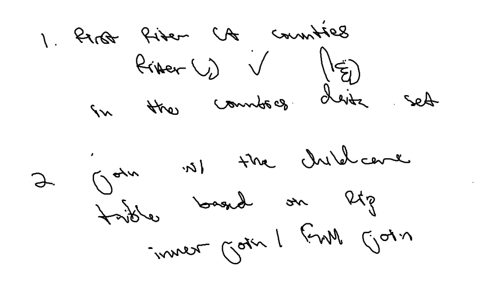

**b. Implement/code your game plan to create the dataset of childcare costs in California.** *Checkpoint: There are 58 counties in CA and 11 years in the dataset. Therefore, your new dataset should have 638 observations.*

```r
# code for Q2
ca_childcare <- counties |>
  filter(state_abbreviation == "CA") |>
  inner_join(childcare_costs,
             by = join_by(county_fips_code))
```

**3. Now, lets add the tax revenue information to the `ca_childcare` dataset. Add the data from `tax_rev` for the counties and years that are already in the `ca_childcare` data. Overwrite the old `ca_childcare` data with this dataset.** *Checkpoint: you are just adding columns here, so your new dataset should still have 638 observations*

```r
# code for Q3
ca_childcare <- ca_childcare |>
  left_join(tax_rev,
            by = join_by(county_name == entity_name, study_year == year))
```

**4. Using a function from the `forcats` package, complete the code below to create a new variable where each county is categorized into one of the [10 Census regions](https://census.ca.gov/regions/) in California. Use the Region description (from the plot), not the Region number.** The code below will help you get started.

```r
# defining 10 census regions

superior_counties <- c("Butte","Colusa","El Dorado",
                       "Glenn","Lassen","Modoc",
                       "Nevada","Placer","Plumas",
                       "Sacramento","Shasta","Sierra","Siskiyou",
                       "Sutter","Tehama","Yolo","Yuba")

north_coast_counties <- c("Del Norte","Humboldt","Lake",
                          "Mendocino","Napa","Sonoma","Trinity")

san_fran_counties <- c("Alameda","Contra Costa","Marin",
                       "San Francisco","San Mateo","Santa Clara",
                       "Solano")

n_san_joaquin_counties <- c("Alpine","Amador","Calaveras","Madera",
                            "Mariposa","Merced","Mono","San Joaquin",
                            "Stanislaus","Tuolumne")

central_coast_counties <- c("Monterey","San Benito","San Luis Obispo",
                            "Santa Barbara","Santa Cruz","Ventura")

s_san_joaquin_counties <- c("Fresno","Inyo","Kern","Kings","Tulare")

inland_counties <- c("Riverside","San Bernardino")

la_county <- "Los Angeles"

orange_county  <- "Orange"

san_diego_imperial_counties <- c("Imperial","San Diego")
```

```r
# finish this code for Q4

ca_childcare <- ca_childcare |>
  mutate(county_name = str_remove(county_name, " County")) |>
  mutate(census_regions = fct_collapse(.f = county_name,
               "Superior California" = superior_counties,
               "North Coast" = north_coast_counties,
               "San Francisco Bay Area" = san_fran_counties,
               "Northern San Joaquin Valley" = n_san_joaquin_counties,
               "Central Coast" = central_coast_counties,
               "Southern San Joaquin Valley" = s_san_joaquin_counties,
               "Inland Empire" = inland_counties,
               "Los Angeles County" = la_county,
               "Orange County" = orange_county,
               "San Diego-Imperial" = san_diego_imperial_counties))
```

**5. Let’s consider the median household income of each region, and how that income has changed over time. Create a table with ten rows, one for each region, and two columns, one for 2008 and one for 2018 (plus a column for region). The cells should contain the `median()` of the median household income (expressed in 2018 dollars) of the `region` and the `study_year`. Order the rows by 2018 values from highest income to lowest income.**

```r
# code for Q5
median_data <- ca_childcare |>
  filter(study_year == 2008 | study_year == 2018) |>
  select(county_fips_code : study_year, mhi_2018, census_regions) |>
  pivot_wider(names_from = study_year,
              values_from = mhi_2018) |>
  group_by(census_regions) |>
  summarise(`2008` = median(`2008`), `2018` = median(`2018`)) |>
  arrange(desc(`2018`))
```

[output not shown]

**6. Which California `region` had the lowest `median` full-time median weekly price for center-based childcare for infants in 2018? Does this `region` correspond to the `region` with the lowest `median` income in 2018 that you found in Q4?**

```r
# code for Q6
ca_childcare |>
  filter(study_year == 2018) |>
  select(county_fips_code : study_year, mc_infant, census_regions) |>
  group_by(census_regions) |>
  summarise(lowest_median = median(mc_infant)) |>
  slice_min(lowest_median) |>
  kable()
```

| census_regions | lowest_median |
| --- | --- |
| Superior California | 215.21 |

**7. The following plot shows, for all ten regions, the change over time of the full-time median price for center-based childcare for infants, toddlers, and preschoolers. Recreate the plot. You do not have to replicate the exact colors or theme, but your plot should have the same content, including the order of the facets and legend, reader-friendly labels, axes breaks, and a loess smoother.**

Plot to recreate

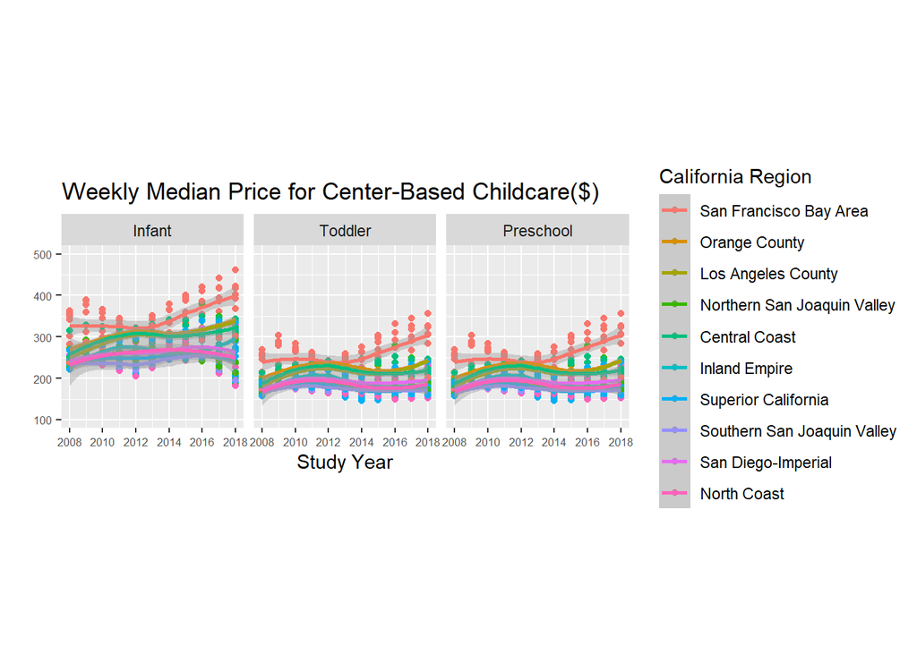

```r
# code for Q7, https://ggplot2.tidyverse.org/reference/scale_continuous.html, https://chatgpt.com/share/680d42c6-aa00-8009-850a-11d11037eae5

age_group_labels <- c(
  mc_infant = "Infant",
  mc_toddler = "Toddler",
  mc_preschool = "Preschool"
)

ca_childcare |>
  select(county_fips_code : study_year, mc_infant : mc_preschool, census_regions) |>
  pivot_longer(cols = mc_infant : mc_preschool,
               names_to = "age_group",
               values_to = "median_price") |>
  mutate(age_group = fct(age_group)) |>
  ggplot(aes(x = study_year, y = median_price, color = fct_reorder2(.x = study_year,
                                                                    .y = median_price,
                                                                    .f = census_regions))) +
  geom_point() +
  geom_smooth(method = loess) +
  facet_wrap(vars(age_group), labeller = labeller(age_group = age_group_labels))  +
  labs(title = "Weekly Median Price for Center-Based Childcare($)", x = "Study Year", y = "", color = "California Region") +
  scale_y_continuous(limits = c(100, 500)) +
  scale_x_continuous(limits = c(2008, 2018), breaks = seq(2008, 2018, 2)) +
  theme(axis.text = element_text(size = 6), aspect.ratio = 1)
```

## Median Household Income vs. Childcare Costs for Infants

**8. Create a scatterplot showing the relationship between median household income (expressed in 2018 dollars) and the full-time median weekly price charged for center-based childcare for an infant in California. Overlay a linear regression line (lm) to show the trend.**

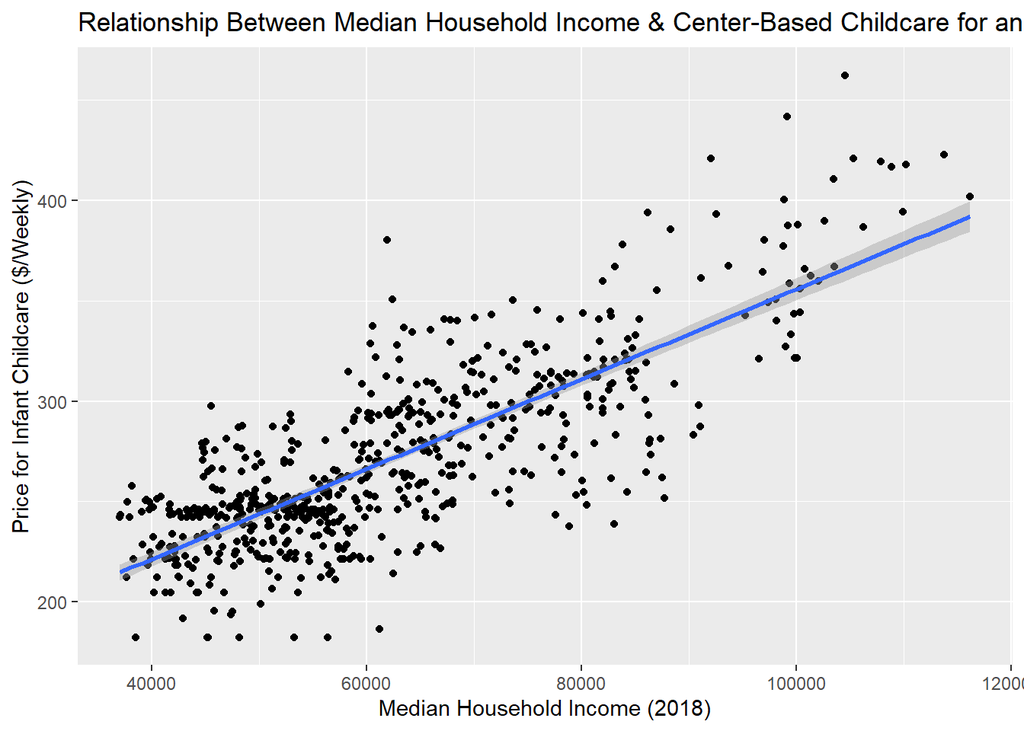

```r
# plot for scatterplot
ca_childcare |>
  ggplot(aes(x = mhi_2018, y = mc_infant)) +
  geom_point() +
  geom_smooth(method = lm) +
  labs(title = "Relationship Between Median Household Income & Center-Based Childcare for an Infant", x = "Median Household Income (2018)", y = "Price for Infant Childcare ($/Weekly)")
```

**9. Look up the documentation for `lm()` and fit a linear regression model to the relationship shown in your plot above (recall: $y = mx+b$). Identify the coefficient estimates from the model.**

```r
# complete the code provided, https://www.datacamp.com/tutorial/linear-regression-R
reg_mod1 <- lm(mc_infant ~ mhi_2018, data = ca_childcare)
summary(reg_mod1)
```

```
Call:
lm(formula = mc_infant ~ mhi_2018, data = ca_childcare)

Residuals:
    Min      1Q  Median      3Q     Max
-82.407 -15.606   0.097  15.999 110.026

Coefficients:
             Estimate Std. Error t value Pr(>|t|)
(Intercept) 1.317e+02  4.321e+00   30.49   <2e-16 ***
mhi_2018    2.241e-03  6.737e-05   33.26   <2e-16 ***
---
Signif. codes:  0 '***' 0.001 '**' 0.01 '*' 0.05 '.' 0.1 ' ' 1

Residual standard error: 27.48 on 636 degrees of freedom
Multiple R-squared:  0.635, Adjusted R-squared:  0.6344
F-statistic:  1106 on 1 and 636 DF,  p-value: < 2.2e-16
```

**10. Do you have evidence to conclude there is a relationship between the median household income and the median weekly cost of center-based childcare for infants in California? Cite values from your output for support.**

There is a moderate relationship between the median household income and the median weekly cost of center-based childcare for infants in California with a $R^2$ of 0.6344, which explains that around 63% of the varibility in the dependent variable can be explained by the median household income.

## Open-Ended Analysis

Let’s give you a taste of what to expect for the take-home portion of the midterm exam.

**11. Investigate the full-time median price for childcare in a center-based setting versus the full-time median price for childcare in a family (in-home) setting in California. Posit a research question. This could include any other variables in the dataset as well. Present one table of summary statistics and one plot that helps to address your research question.**

**Description**:The data is the full-time median weekly price for childcare in a center-based setting for infants (age 0) to preschoolers (age 54 months) and full-time weekly median price for childcare in a family (in-home) setting in California per census region.

**Research Question**: Is the full-time median price for childcare in a center-based setting more expensive than the full-time median price for childcare in a family (in-home) setting in California?

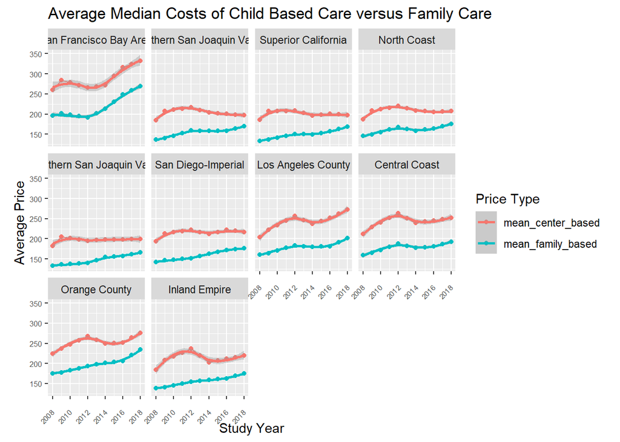

```r
 research_center_based <- ca_childcare |>
  select(county_fips_code : study_year, mc_infant : mc_preschool, census_regions) |>
  pivot_longer(cols = mc_infant : mc_preschool,
           names_to = "center_based",
           values_to = "median_price") |>
  group_by(study_year, census_regions) |>
  summarise("mean_center_based" = mean(median_price), .groups = "drop") |>
  arrange(census_regions)

research_family_based <- ca_childcare |>
  select(county_fips_code : study_year, mfcc_infant : mfcc_preschool, census_regions) |>
  pivot_longer(cols = mfcc_infant : mfcc_preschool,
           names_to = "family_based",
           values_to = "median_price") |>
  group_by(study_year, census_regions) |>
  summarise("mean_family_based" = mean(median_price), .groups = "drop") |>
  arrange(census_regions)

combined <- inner_join(research_center_based, research_family_based)

combined_longer <- combined |>
  pivot_longer(cols = mean_center_based : mean_family_based,
               names_to = "price_type",
               values_to = "mean_price")

ggplot(data = combined_longer, aes(x = study_year, y = mean_price, color = price_type)) +
  geom_line() +
  geom_point() +
  geom_smooth(method = loess) +
  labs(title = "Average Median Costs of Child Based Care versus Family Care", x = "Study Year", y = "Average Price", color = "Price Type") +
  scale_x_continuous(limits = c(2008, 2018), breaks = seq(2008, 2018, 2)) +
  facet_wrap(vars(census_regions)) +
  theme(axis.text = element_text(size = 6), aspect.ratio = 1, axis.text.x = element_text(angle = 45, vjust = 0.5, hjust=1))
```